# Climate Extremes Analysis

Abigail Sanford, Julia Bickford, Andrea Cornelius

4/17/2023

# Read in the Data

```r
knitr::opts_chunk$set(echo = TRUE)

# load pacakges
library(lubridate)
library(tidyverse)
climtherm <- read.table("thermal_precip_temp.csv", fill=TRUE, sep=',', header=T) # read in the data

head(climtherm) #this lets us look at our data table in the Rmarkdown rather than having to navigate to the data table in the environment
```

```
##       STATION                                   NAME      DATE PRCP TMAX TMIN
## 1 USW00003104 DESERT RESORTS REGIONAL AIRPORT, CA US 5/12/1950    0   NA   NA
## 2 USW00003104 DESERT RESORTS REGIONAL AIRPORT, CA US 5/13/1950    0   94   67
## 3 USW00003104 DESERT RESORTS REGIONAL AIRPORT, CA US 5/14/1950    0   95   65
## 4 USW00003104 DESERT RESORTS REGIONAL AIRPORT, CA US 5/15/1950    0   98   64
## 5 USW00003104 DESERT RESORTS REGIONAL AIRPORT, CA US 5/16/1950    0   97   64
## 6 USW00003104 DESERT RESORTS REGIONAL AIRPORT, CA US 5/17/1950    0   88   63
```

```r
climtidy <- climtherm %>%
  select(DATE, PRCP, TMAX, TMIN) %>% # selected the columns I want to keep which include date, precipitation, temperature max, and temperature minimum
  mutate(DATE = mdy(DATE)) %>% # converts the date column into the 'date' class
  mutate(YEAR = year(DATE)) # Create new column with just the year in it
```

# How many heat wave days are there per year?

### Heatwave Threshold set to 80F

```r
heatwavedays <- climtidy %>%
  mutate(HEATWAVE = ifelse(climtidy$TMAX >= 80, 1, 0)) %>% # created a new column that puts a 1 down if temp was 80F or higher, and a 0 for all other temperatures. If different heatwave threshold is selected, change the 80 to the new heatwave threshold
  drop_na() # remove NA values, this removed 26 observations
```

```r
# look at data in a chart

heatwavedaystidy <- heatwavedays %>%
  select(YEAR, HEATWAVE) %>% # pull out only year and heatwave columns
  group_by(YEAR) %>% # have r recognize that the data can be organized into years
  summarise(across(c(HEATWAVE), # add up the number of days a heat wave has occurred in each year
                   list(sum = sum)))

heatwavedaystidy # view table
```

```
## # A tibble: 73 x 2
##     YEAR HEATWAVE_sum
##    <dbl>        <dbl>
##  1  1950          207
##  2  1951          243
##  3  1952          230
##  4  1953          263
##  5  1954          270
##  6  1955          241
##  7  1956          247
##  8  1957          238
##  9  1958          243
## 10  1959          269
## # ... with 63 more rows
```

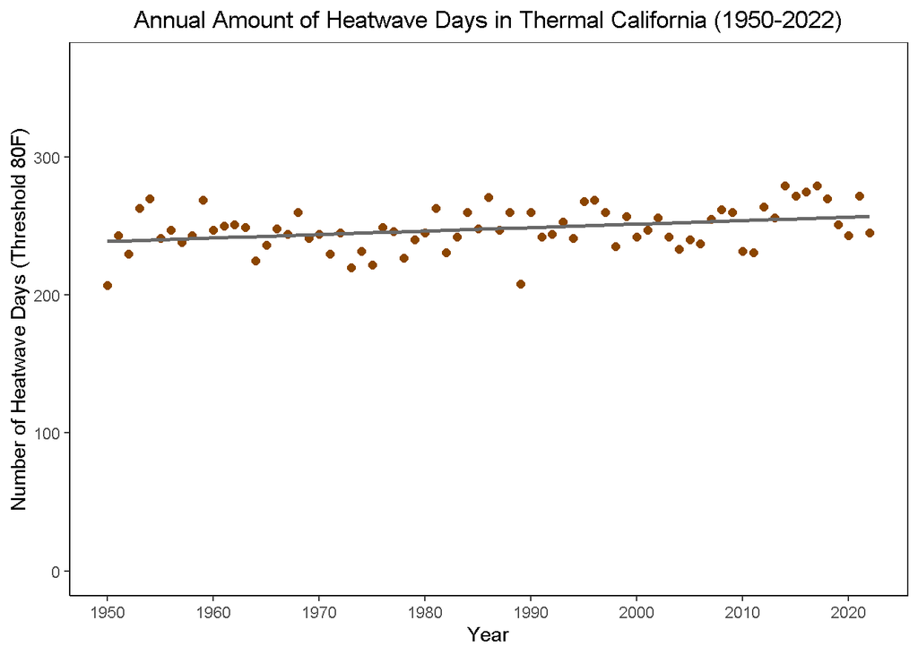

```r
# visualize heatwave days in a graph

ggplot(heatwavedaystidy, aes(x = YEAR, y = HEATWAVE_sum)) +
  geom_point(color = "darkorange4", size = 2) +
  geom_smooth(method = 'lm', se = FALSE, color = "dimgrey") +
  labs(y = "Number of Heatwave Days (Threshold 80F)",
       x = "Year",
       title = "Annual Amount of Heatwave Days in Thermal California (1950-2022)") +
  theme_bw() +
  theme(plot.title = element_text(hjust = 0.5),
        panel.grid.major = element_blank(),
        panel.grid.minor = element_blank(),
        axis.line = element_line(color = "black")) +
    ylim(0, 365) +
  scale_x_continuous(breaks = c(1950, 1960, 1970, 1980, 1990, 2000, 2010, 2020))
```

#### Brief Analysis There is a slight increasing trend in the amount of heatwave days per year, given that our heat wave threshold is 80F

### Heatwave Threshold set to 90F

```r
heatwavedays90 <- climtidy %>%
  mutate(HEATWAVE = ifelse(climtidy$TMAX >= 90, 1, 0)) %>% # created a new column that puts a 1 down if temp was 90F or higher, and a 0 for all other temperatures. If different heatwave threshold is selected, change the 90 to the new heatwave threshold
  drop_na() # remove NA values
```

```r
# look at data in a chart

heatwavedaystidy90 <- heatwavedays90 %>%
  select(YEAR, HEATWAVE) %>% # pull out only year and heatwave columns
  group_by(YEAR) %>% # have r recognize that the data can be organized into years
  summarise(across(c(HEATWAVE), # add up the number of days a heat wave has occurred in each year
                   list(sum = sum)))

heatwavedaystidy90 # view table
```

```
## # A tibble: 73 x 2
##     YEAR HEATWAVE_sum
##    <dbl>        <dbl>
##  1  1950          177
##  2  1951          178
##  3  1952          192
##  4  1953          168
##  5  1954          199
##  6  1955          173
##  7  1956          179
##  8  1957          159
##  9  1958          182
## 10  1959          189
## # ... with 63 more rows
```

```r
# create a chart, but only include the top 10 heat wave years
```

[output not shown]

[output not shown]

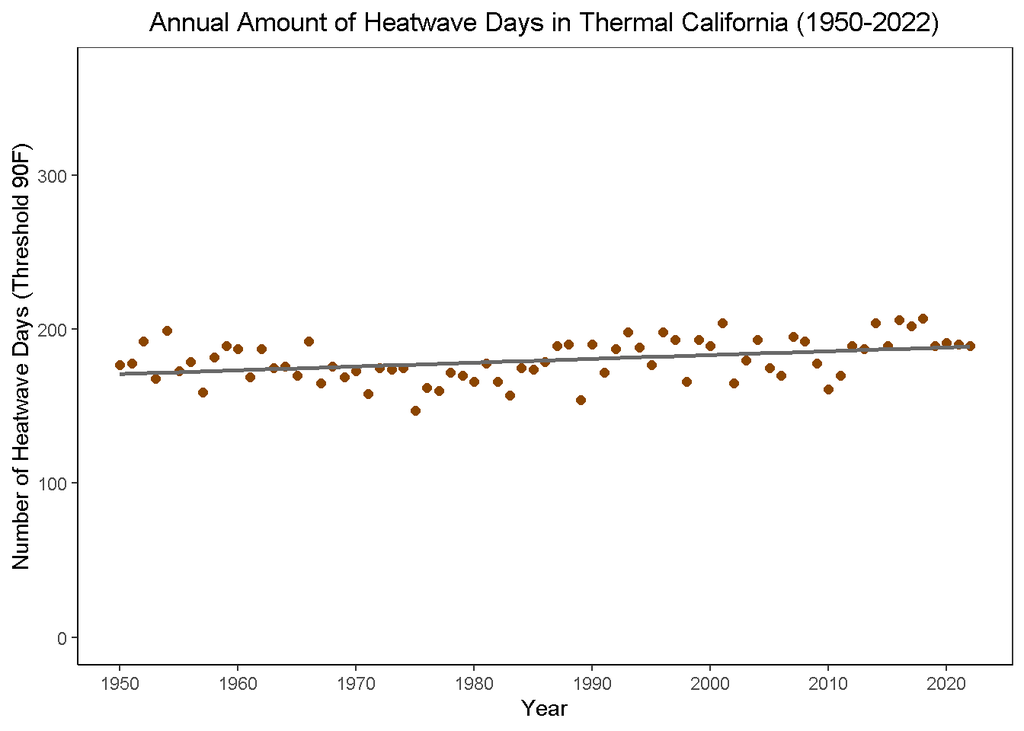

```r
# visualize heatwave days in a graph

ggplot(heatwavedaystidy90, aes(x = YEAR, y = HEATWAVE_sum)) +
  geom_point(color = "darkorange4", size = 2) +
  geom_smooth(method = 'lm', se = FALSE, color = "dimgrey") +
  labs(y = "Number of Heatwave Days (Threshold 90F)",
       x = "Year",
       title = "Annual Amount of Heatwave Days in Thermal California (1950-2022)") +
  theme_bw() +
  theme(plot.title = element_text(hjust = 0.5),
        panel.grid.major = element_blank(),
        panel.grid.minor = element_blank(),
        axis.line = element_line(color = "black")) +
    ylim(0, 365) +
  scale_x_continuous(breaks = c(1950, 1960, 1970, 1980, 1990, 2000, 2010, 2020))
```

### Heatwave Threshold set to 100F

```r
heatwavedays100 <- climtidy %>%
  mutate(HEATWAVE = ifelse(climtidy$TMAX >= 100, 1, 0)) %>% # created a new column that puts a 1 down if temp was 100F or higher, and a 0 for all other temperatures. If different heatwave threshold is selected, change the 100 to the new heatwave threshold
  drop_na() # remove NA values
```

```r
# look at data in a chart

heatwavedaystidy100 <- heatwavedays100 %>%
  select(YEAR, HEATWAVE) %>% # pull out only year and heatwave columns
  group_by(YEAR) %>% # have r recognize that the data can be organized into years
  summarise(across(c(HEATWAVE), # add up the number of days a heat wave has occurred in each year
                   list(sum = sum)))

heatwavedaystidy100 # view table
```

```
## # A tibble: 73 x 2
##     YEAR HEATWAVE_sum
##    <dbl>        <dbl>
##  1  1950           99
##  2  1951          119
##  3  1952          134
##  4  1953          111
##  5  1954          105
##  6  1955           95
##  7  1956          117
##  8  1957          107
##  9  1958          138
## 10  1959          106
## # ... with 63 more rows
```

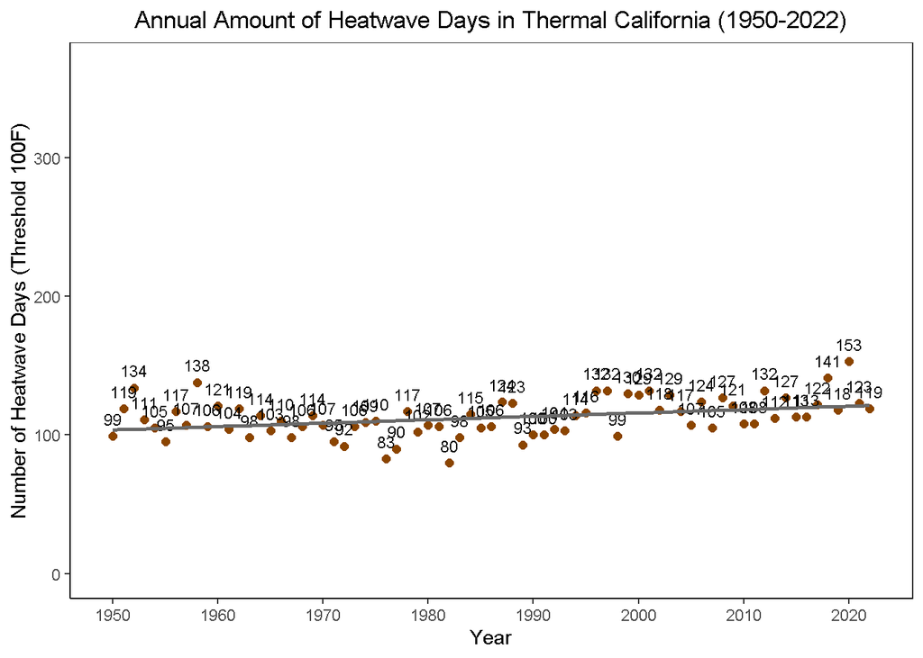

```r
# visualize heatwave days in a graph

ggplot(heatwavedaystidy100, aes(x = YEAR, y = HEATWAVE_sum)) +
  geom_point(color = "darkorange4", size = 2) +
  geom_text(mapping = aes (label = HEATWAVE_sum),
            position = position_dodge(width = 0.9),
            cex = 3,
            vjust = -0.9) +
  geom_smooth(method = 'lm', se = FALSE, color = "dimgrey") +
  labs(y = "Number of Heatwave Days (Threshold 100F)",
       x = "Year",
       title = "Annual Amount of Heatwave Days in Thermal California (1950-2022)") +
  theme_bw() +
  theme(plot.title = element_text(hjust = 0.5),
        panel.grid.major = element_blank(),
        panel.grid.minor = element_blank(),
        axis.line = element_line(color = "black")) +
    ylim(0, 365) +
  scale_x_continuous(breaks = c(1950, 1960, 1970, 1980, 1990, 2000, 2010, 2020))
```

### Heatwave Threshold set to 110F

```r
heatwavedays110 <- climtidy %>%
  mutate(HEATWAVE = ifelse(climtidy$TMAX >= 110, 1, 0)) %>% # created a new column that puts a 1 down if temp was 110F or higher, and a 0 for all other temperatures. If different heatwave threshold is selected, change the 110 to the new heatwave threshold
  drop_na() # remove NA values
```

```r
# look at data in a chart

heatwavedaystidy110 <- heatwavedays110 %>%
  select(YEAR, HEATWAVE) %>% # pull out only year and heatwave columns
  group_by(YEAR) %>% # have r recognize that the data can be organized into years
  summarise(across(c(HEATWAVE), # add up the number of days a heat wave has occurred in each year
                   list(sum = sum)))

heatwavedaystidy110 # view table
```

```
## # A tibble: 73 x 2
##     YEAR HEATWAVE_sum
##    <dbl>        <dbl>
##  1  1950           27
##  2  1951           31
##  3  1952           32
##  4  1953           33
##  5  1954           16
##  6  1955           19
##  7  1956           20
##  8  1957           30
##  9  1958           23
## 10  1959           25
## # ... with 63 more rows
```

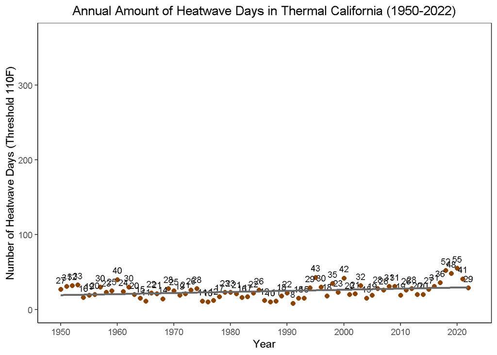

```r
# visualize heatwave days in a graph

ggplot(heatwavedaystidy110, aes(x = YEAR, y = HEATWAVE_sum)) +
  geom_point(color = "darkorange4", size = 2) +
  geom_text(mapping = aes (label = HEATWAVE_sum),
            position = position_dodge(width = 0.9),
            cex = 3,
            vjust = -0.9) +
  geom_smooth(method = 'lm', se = FALSE, color = "dimgrey") +
  labs(y = "Number of Heatwave Days (Threshold 110F)",
       x = "Year",
       title = "Annual Amount of Heatwave Days in Thermal California (1950-2022)") +
  theme_bw() +
  theme(plot.title = element_text(hjust = 0.5),
        panel.grid.major = element_blank(),
        panel.grid.minor = element_blank(),
        axis.line = element_line(color = "black")) +
    ylim(0, 365) +
  scale_x_continuous(breaks = c(1950, 1960, 1970, 1980, 1990, 2000, 2010, 2020))
```

### Heatwave Threshold set to 120F

```r
heatwavedays120 <- climtidy %>%
  mutate(HEATWAVE = ifelse(climtidy$TMAX >= 120, 1, 0)) %>% # created a new column that puts a 1 down if temp was 80F or higher, and a 0 for all other temperatures. If different heatwave threshold is selected, change the 80 to the new heatwave threshold
  drop_na() # remove NA values
```

```r
# look at data in a chart

heatwavedaystidy120 <- heatwavedays120 %>%
  select(YEAR, HEATWAVE) %>% # pull out only year and heatwave columns
  group_by(YEAR) %>% # have r recognize that the data can be organized into years
  summarise(across(c(HEATWAVE), # add up the number of days a heat wave has occurred in each year
                   list(sum = sum)))

heatwavedaystidy120 # view table
```

```
## # A tibble: 73 x 2
##     YEAR HEATWAVE_sum
##    <dbl>        <dbl>
##  1  1950            3
##  2  1951            0
##  3  1952            0
##  4  1953            0
##  5  1954            0
##  6  1955            0
##  7  1956            0
##  8  1957            0
##  9  1958            0
## 10  1959            0
## # ... with 63 more rows
```

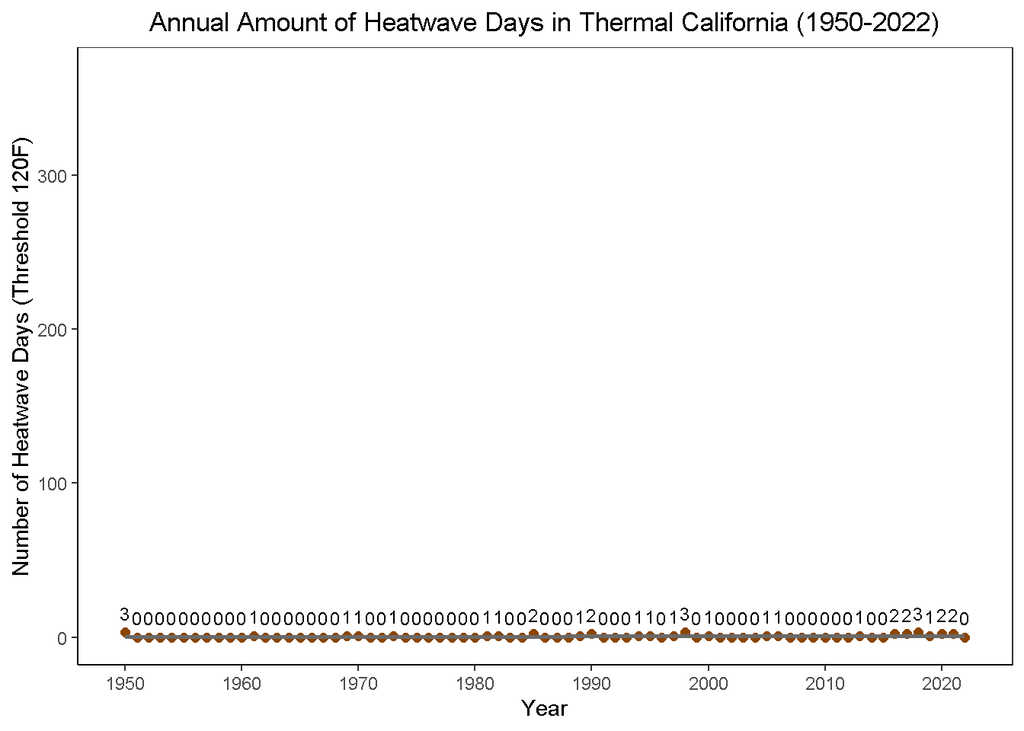

```r
# visualize heatwave days in a graph

ggplot(heatwavedaystidy120, aes(x = YEAR, y = HEATWAVE_sum)) +
  geom_point(color = "darkorange4", size = 2) +
  geom_text(mapping = aes (label = HEATWAVE_sum),
            position = position_dodge(width = 0.9),
            cex = 3,
            vjust = -0.9) +
  geom_smooth(method = 'lm', se = FALSE, color = "dimgrey") +
  labs(y = "Number of Heatwave Days (Threshold 120F)",
       x = "Year",
       title = "Annual Amount of Heatwave Days in Thermal California (1950-2022)") +
  theme_bw() +
  theme(plot.title = element_text(hjust = 0.5),
        panel.grid.major = element_blank(),
        panel.grid.minor = element_blank(),
        axis.line = element_line(color = "black")) +
    ylim(0, 365) +
  scale_x_continuous(breaks = c(1950, 1960, 1970, 1980, 1990, 2000, 2010, 2020))
```

# How many days with precipitation

### Extremes metrics: return periods

In lecture, we discussed the concept of return periods and return levels. Here is how you calculate these things with real data!

We’ll specify some reasonable threshold for daily precipitation: say, 1 inch/day. To calculate the return period associated with that threshold, what we do is the following: * Use `ifelse` to create a field called “drought” that is 1 when precipitation is below the threshold, and 0 otherwise * Store the total number of years by first identifying the total number of unique years, then calculating the length of the array where those unique years are listed

The return period is then the number of years (plus one to include the starting year) divided by the number of times the threshold exceedance has actually occurred. (Note: we have to use the `na.rm=TRUE` flag to prevent NA entries from seeming like they are contributing to the count of threshold exceedances!)

```r
droughtdays <- climtidy %>%
  mutate(DROUGHT = ifelse(climtidy$PRCP <= 1, 1, 0)) %>% # If there is less than 1 inch of rain on that day, then put a 1 in the drought column

  drop_na()
```

```r
totaldroughtdays <- droughtdays %>%
  select(YEAR, DROUGHT) %>% # pull out only year and drought columns
  group_by(YEAR) %>% # have r recognize that the data can be organized into years
  summarise(across(c(DROUGHT), # add up the number of days a drought has occurred in each year
                   list(sum = sum)))

totaldroughtdays # View table
```

```
## # A tibble: 73 x 2
##     YEAR DROUGHT_sum
##    <dbl>       <dbl>
##  1  1950         233
##  2  1951         365
##  3  1952         364
##  4  1953         365
##  5  1954         365
##  6  1955         365
##  7  1956         366
##  8  1957         365
##  9  1958         364
## 10  1959         364
## # ... with 63 more rows
```

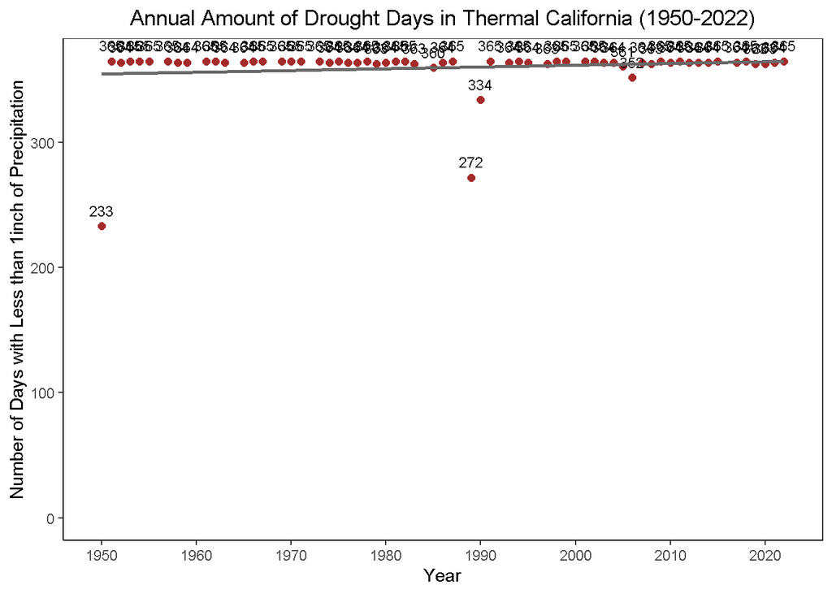

```r
# Loosing my damn mind aka visualizing the precipitation

ggplot(totaldroughtdays, aes(x = YEAR, y = DROUGHT_sum)) +
  geom_point(color = "brown", size = 2) +
  geom_text(mapping = aes (label = DROUGHT_sum),
            position = position_dodge(width = 0.9),
            cex = 3,
            vjust = -0.9) +
  geom_smooth(method = 'lm', se = FALSE, color = "dimgrey") +
  labs(y = "Number of Days with Less than 1inch of Precipitation",
       x = "Year",
       title = "Annual Amount of Drought Days in Thermal California (1950-2022)") +
  theme_bw() +
  theme(plot.title = element_text(hjust = 0.5),
        panel.grid.major = element_blank(),
        panel.grid.minor = element_blank(),
        axis.line = element_line(color = "black")) +
    ylim(0, 365) +
  scale_x_continuous(breaks = c(1950, 1960, 1970, 1980, 1990, 2000, 2010, 2020))
```

```r
totaldroughtdays <- climtidy %>%
  select(YEAR, PRCP) %>% # pull out only year and drought columns
  group_by(YEAR) %>% # have r recognize that the data can be organized into years
  summarise(across(c(PRCP), # add up the number of days a drought has occurred in each year
                   list(sum = sum)))

totaldroughtdays # View table
```

```
## # A tibble: 73 x 2
##     YEAR PRCP_sum
##    <dbl>    <dbl>
##  1  1950     0.31
##  2  1951     1.91
##  3  1952     5.47
##  4  1953     0.32
##  5  1954     1.76
##  6  1955     2.48
##  7  1956     0.49
##  8  1957     2.22
##  9  1958     2.94
## 10  1959     2.65
## # ... with 63 more rows
```

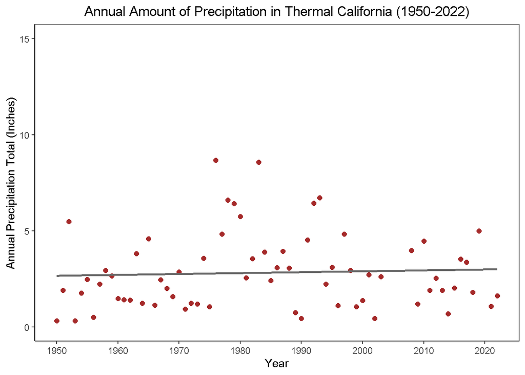

```r
# Loosing my damn mind aka visualizing the precipitation

ggplot(totaldroughtdays, aes(x = YEAR, y = PRCP_sum)) +
  geom_point(color = "brown", size = 2) +
  geom_smooth(method = 'lm', se = FALSE, color = "dimgrey") +
  labs(y = "Annual Precipitation Total (Inches)",
       x = "Year",
       title = "Annual Amount of Precipitation in Thermal California (1950-2022)") +
  theme_bw() +
  theme(plot.title = element_text(hjust = 0.5),
        panel.grid.major = element_blank(),
        panel.grid.minor = element_blank(),
        axis.line = element_line(color = "black")) +
    ylim(0, 15) +
  scale_x_continuous(breaks = c(1950, 1960, 1970, 1980, 1990, 2000, 2010, 2020))
```

# But what is actually important is figuring out how long it will be until the next wet period. Since the area has a lot of agriculture buisnesses.

```r
returnperiod=(totaldroughtdays+1)/sum(droughtdays$DROUGHT,na.rm=TRUE)

returnperiod
```

```
##          YEAR     PRCP_sum
## 1  0.07405580 4.972481e-05
## 2  0.07409376 1.104574e-04
## 3  0.07413171 2.455874e-04
## 4  0.07416967 5.010438e-05
## 5  0.07420763 1.047637e-04
## 6  0.07424559 1.320934e-04
## 7  0.07428355 5.655722e-05
## 8  0.07432150 1.222243e-04
## 9  0.07435946 1.495540e-04
## 10 0.07439742 1.385462e-04
## 11 0.07443538 9.375593e-05
## 12 0.07447333 9.185804e-05
## 13 0.07451129 9.071930e-05
## 14 0.07454925 1.825773e-04
```

[output cut: 59 more lines]

We’ll specify some reasonable threshold for drought precipitation amounts is less than 1 inch/day. To calculate the return period associated with that threshold, what we do is the following:

- Use `ifelse` to create a field called “drought” that is 1 when precipitation is below the threshold, and 0 otherwise

The return period is then the number of years (plus one to include the starting year) divided by the number of times the threshold exceedance has actually occurred. (Note: we have to use the `na.rm=TRUE` flag to prevent NA entries from seeming like they are contributing to the count of threshold exceedances!)

Another note: return *levels* are somewhat more complicated to calculate, since they require fitting the underlying distribution of the data… there are lots of resources out there if you need them though!